# Tarea 4

## ----------------------------------------------------------------------------------------------------------------

### Ejercicio 1.

#### a) Cargue la tabla de datos titanic.csv

```python
import pandas as pd
import os

os.chdir("D:/Descargas/")
datos_titanic = pd.read_csv('Titanic.csv',delimiter=',',decimal=".")
```

#### b) Recodique las variables cualitativas que están codicadas con números e ignore variables que no se deben usar, es decir, con valor único.

```python
def recodificar(col, nuevo_codigo):
  col_cod = pd.Series(col, copy=True)
  for llave, valor in nuevo_codigo.items():
    col_cod.replace(llave, valor, inplace=True)
  return col_cod

datos_titanic["Pclass"] = recodificar(datos_titanic["Pclass"], {1:'primera',2:'segunda',3:'tercera'})
datos_titanic["Survived"] = recodificar(datos_titanic["Survived"], {0:'no',1:'si'})
datos_titanic = datos_titanic.fillna(np.mean(datos_titanic))
datos_titanic_ign = datos_titanic.drop(['PassengerId','Name','Ticket','Cabin'], 1)
datos_dummy = pd.get_dummies(datos_titanic_ign)

print(datos_titanic_ign.head())
```

```
  Survived   Pclass     Sex   Age  SibSp  Parch     Fare Embarked
0       no  tercera    male  22.0      1      0   7.2500        S
1       si  primera  female  38.0      1      0  71.2833        C
2       si  tercera  female  26.0      0      0   7.9250        S
3       si  primera  female  35.0      1      0  53.1000        S
4       no  tercera    male  35.0      0      0   8.0500        S
```

#### c) Calcule todas las estadísticas básicas en esta tabla de datos, incluya los análisis vistos en clase para variables numéricas.

```python
import numpy as np
print("\n",datos_titanic_ign['Survived'].value_counts())
print("\n\n",datos_titanic_ign['Pclass'].value_counts())
print("\n\n",datos_titanic_ign['Embarked'].value_counts())
print("\n\n",datos_titanic_ign['Sex'].value_counts())

print("\nMEAN:\n",datos_dummy.mean(numeric_only=True))
print("\nMEDIAN:\n",datos_dummy.median(numeric_only=True))
print("\nSTD:\n",datos_dummy.std(numeric_only=True))
print("\nMAX:\n",datos_titanic_ign.max(numeric_only=True))
print("\nMIN:\n",datos_titanic_ign.min(numeric_only=True))
print("\nPERCENTILES:\n",datos_dummy.quantile(np.array([0,.25,.50,.75,1])))

print("\nRESUMEN:\n",datos_dummy.describe())
```

```
 no    815
si    492
Name: Survived, dtype: int64


 tercera    709
primera    321
segunda    277
Name: Pclass, dtype: int64


 S    914
C    270
Q    123
Name: Embarked, dtype: int64


 male      843
female    464
Name: Sex, dtype: int64

MEAN:
 Age               29.842596
SibSp              0.499617
Parch              0.385616
Fare              33.223956
Survived_no        0.623565
Survived_si        0.376435
Pclass_primera     0.245601
Pclass_segunda     0.211936
Pclass_tercera     0.542464
Sex_female         0.355011
Sex_male           0.644989
Embarked_C         0.206580
Embarked_Q         0.094109
Embarked_S         0.699311
dtype: float64

MEDIAN:
 Age               28.0000
```

[output cut: 83 more lines]

```
min       0.000000        0.000000        0.000000        0.000000
25%       0.000000        0.000000        0.000000        0.000000
50%       0.000000        0.000000        0.000000        1.000000
75%       1.000000        0.000000        0.000000        1.000000
max       1.000000        1.000000        1.000000        1.000000

        Sex_female     Sex_male   Embarked_C   Embarked_Q   Embarked_S
count  1307.000000  1307.000000  1307.000000  1307.000000  1307.000000
mean      0.355011     0.644989     0.206580     0.094109     0.699311
std       0.478700     0.478700     0.405006     0.292092     0.458733
min       0.000000     0.000000     0.000000     0.000000     0.000000
25%       0.000000     0.000000     0.000000     0.000000     0.000000
50%       0.000000     1.000000     0.000000     0.000000     1.000000
75%       1.000000     1.000000     0.000000     0.000000     1.000000
max       1.000000     1.000000     1.000000     1.000000     1.000000
```

#### d) Realice gráficos de barras que ayuden a determinar la distribución de las variables categóricas.

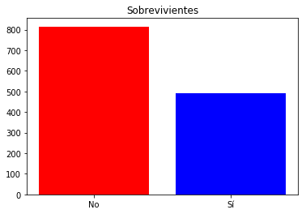

```python
import matplotlib.pyplot as plt


g_survived = pd.crosstab(index=datos_titanic_ign["Survived"],columns="count")
alto = [g_survived['count'][0], g_survived['count'][1]]
barras = ('No', 'Sí')
y_pos = np.arange(len(barras))
plt.bar(y_pos, alto, color=['red','blue'])
plt.xticks(y_pos, barras)
plt.title("Sobrevivientes")
```

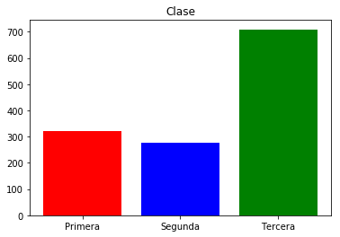

```python
g_class = pd.crosstab(index=datos_titanic_ign["Pclass"],columns="count")
clases = [g_class['count'][0], g_class['count'][1], g_class['count'][2]]
barras = ('Primera', 'Segunda', 'Tercera')
y_pos = np.arange(len(barras))
plt.bar(y_pos, clases, color=['red','blue','green'])
plt.xticks(y_pos, barras)
plt.title("Clase")
```

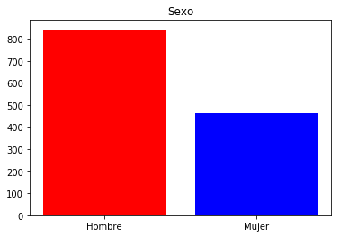

```python
g_sex = pd.crosstab(index=datos_titanic_ign["Sex"],columns="count")
clases = [g_sex['count'][1], g_sex['count'][0]]
barras = ('Hombre', 'Mujer')
y_pos = np.arange(len(barras))
plt.bar(y_pos, clases, color=['red','blue'])
plt.xticks(y_pos, barras)
plt.title("Sexo")
```

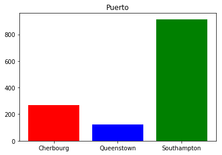

```python
g_embark = pd.crosstab(index=datos_titanic_ign["Embarked"],columns="count")
clases = [g_embark['count'][0], g_embark['count'][1], g_embark['count'][2]]
barras = ('Cherbourg', 'Queenstown', 'Southampton')
y_pos = np.arange(len(barras))
plt.bar(y_pos, clases, color=['red','blue','green'])
plt.xticks(y_pos, barras)
plt.title("Puerto")
```

#### e) Realice gráficos tipo boxplot para encontrar los datos atípicos en esta tabla de datos.

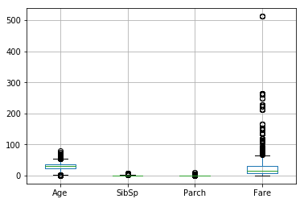

```python
boxplots = datos_titanic_ign.boxplot(return_type='axes')
```

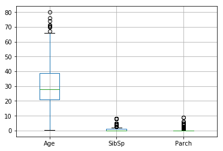

```python
boxplots = datos_titanic_ign.drop(['Fare'], 1).boxplot(return_type='axes')
```

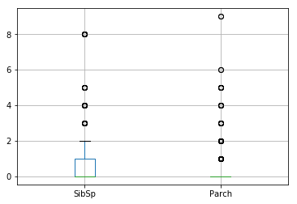

```python
boxplots = datos_titanic_ign.drop(['Fare','Age'], 1).boxplot(return_type='axes')
```

#### f ) Realice histogramas, gráficos de la función de densidad y test de normalidad para al menosdos variables de esta tabla de datos.

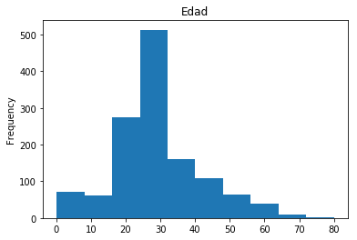

```python
histogramaEdad = datos_titanic_ign['Age'].plot(kind='hist',title='Edad')
```

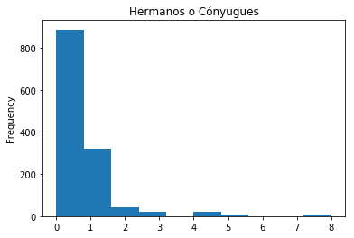

```python
histogramaSiblings = datos_titanic_ign['SibSp'].plot(kind='hist',title='Hermanos o Cónyugues')
```

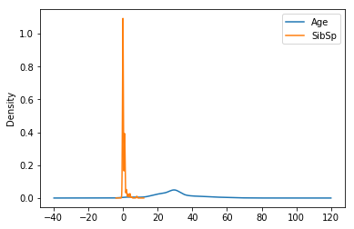

```python
densidad = datos_titanic_ign[['Age','SibSp']].plot(kind='density')
```

```
EDAD
(0.9574840068817139, 4.64888118759143e-19)
No sigue la curva Normal (Se rechaza H0)
```

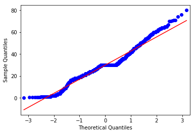

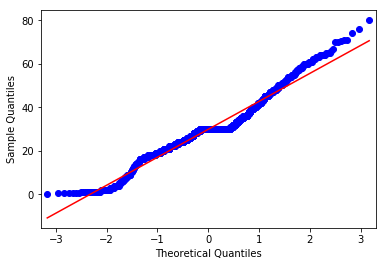

```python
import scipy.stats
from statsmodels.graphics.gofplots import qqplot
print('EDAD')
shapiro_resultados = scipy.stats.shapiro(datos_titanic_ign['Age'].fillna(np.mean(datos_titanic_ign['Age'])))
print(shapiro_resultados)
p_value = shapiro_resultados[1]
alpha = 0.05
if p_value > alpha:
    print('Sí sigue la curva Normal (No se rechaza H0)')
else:
    print('No sigue la curva Normal (Se rechaza H0)')


qqplot(datos_titanic_ign.Age, line='s')
```

```
Hermanos o Cónyugues
(0.5114514827728271, 0.0)
No sigue la curva Normal (Se rechaza H0)
```

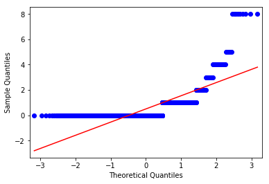

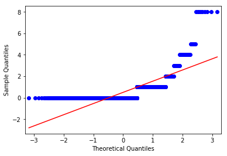

```python
print('Hermanos o Cónyugues')
shapiro_resultados = scipy.stats.shapiro(datos_titanic_ign['SibSp'].fillna(np.mean(datos_titanic_ign['SibSp'])))
print(shapiro_resultados)
p_value = shapiro_resultados[1]
alpha = 0.05
if p_value > alpha:
    print('Sí sigue la curva Normal (No se rechaza H0)')
else:
    print('No sigue la curva Normal (Se rechaza H0)')


qqplot(datos_titanic_ign.SibSp, line='s')
```

#### g) Realice al menos dos scatter plot individuales y un gráfico de todas las variables 2 a 2 usando el paquete Seaborn.

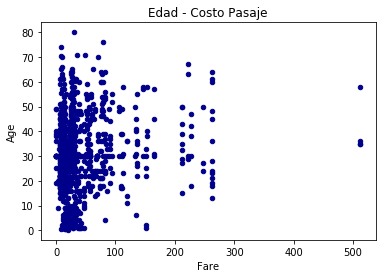

```python
a = datos_titanic_ign[['Age','Fare']].plot.scatter(x='Fare',y='Age',c='DarkBlue', title='Edad - Costo Pasaje')
```

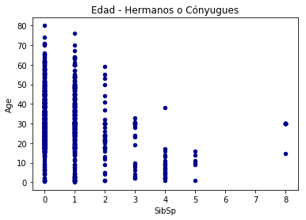

```python
b = datos_titanic_ign[['Age','SibSp']].plot.scatter(x='SibSp',y='Age',c='DarkBlue', title='Edad - Hermanos o Cónyugues')
```

```
gráfico de todas las variables 2 a 2
```

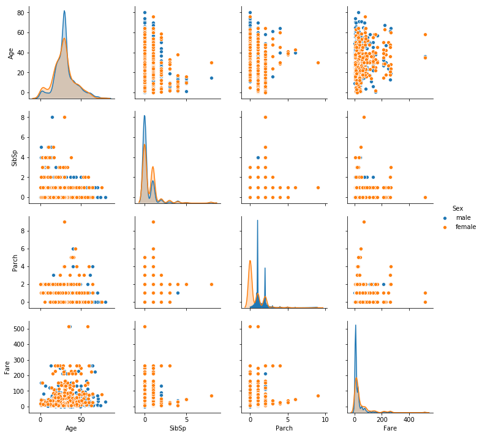

```python
import seaborn as sns
print('gráfico de todas las variables 2 a 2')
sea = sns.pairplot(datos_titanic_ign, hue='Sex', size=2.5)
```

#### h. Calcule y grafique la matriz de correlaciones.

```
            Age     SibSp     Parch      Fare
Age    1.000000 -0.190107 -0.130058  0.170052
SibSp -0.190107  1.000000  0.373383  0.161015
Parch -0.130058  0.373383  1.000000  0.222310
Fare   0.170052  0.161015  0.222310  1.000000
```

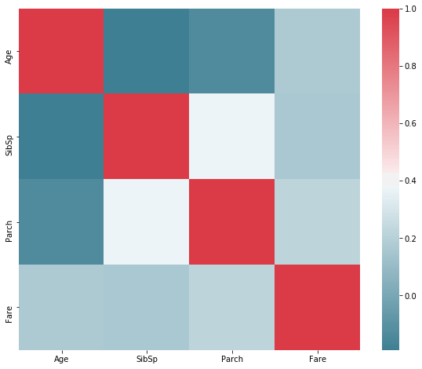

```python
import matplotlib.pyplot as plt
corr = datos_titanic_ign.corr()
print(corr)
print("\n")
f, ax = plt.subplots(figsize=(10, 8))
graf = sns.heatmap(corr, mask=np.zeros_like(corr, dtype=np.bool), cmap=sns.diverging_palette(220, 10, as_cmap=True),square=True, ax=ax)
```

## ---------------------------------------------------------------------------------------------------------------------------

### Ejercicio 2

#### [25 puntos] Para la tabla SAheart.csv la cual contiene variables numéricas y categóricas mezcladas. La descripción de los datos es la siguiente: Datos Tomados del libro: The Elements of Statistical Learning Data Mining, Inference, and Prediction de Trevor Hastie, Robert Tibshirani y Jerome Friedman de la Universidad de Stanford.

#### a) Cargue la tabla de datos SAheart.csv

```python
os.chdir("D:/ProyectosGit/MineriaDatos/csv/")
datos_heart = pd.read_csv('SAheart.csv',delimiter=';',decimal=".")
```

#### b) Recodique las variables cualitativas que están codicadas con números e ignore variables que no se deben usar, es decir, con valor único.

```python
datos_dummy_heart = pd.get_dummies(datos_heart)

print(datos_heart.head())
```

```
   sbp  tobacco   ldl  adiposity  famhist  typea  obesity  alcohol  age chd
0  160    12.00  5.73      23.11  Present     49    25.30    97.20   52  Si
1  144     0.01  4.41      28.61   Absent     55    28.87     2.06   63  Si
2  118     0.08  3.48      32.28  Present     52    29.14     3.81   46  No
3  170     7.50  6.41      38.03  Present     51    31.99    24.26   58  Si
4  134    13.60  3.50      27.78  Present     60    25.99    57.34   49  Si
```

#### c) Calcule todas las estadísticas básicas en esta tabla de datos, incluya los análisis vistos en clase para variables numéricas.

```python
print("\n Cantidad de individuos con historia familiar de infarto\n",datos_heart['famhist'].value_counts())
print("\n\n Cantidad de individuos que murieron de enfermedad cardiaca coronaria\n",datos_heart['chd'].value_counts())

print("\nRESUMEN:\n",datos_dummy_heart.describe())

print("\nMEAN:\n",datos_dummy_heart.mean(numeric_only=True))
print("\nMEDIAN:\n",datos_dummy_heart.median(numeric_only=True))
print("\nSTD:\n",datos_dummy_heart.std(numeric_only=True))
print("\nMAX:\n",datos_heart.max(numeric_only=True))
print("\nMIN:\n",datos_heart.min(numeric_only=True))
print("\nPERCENTILES:\n",datos_dummy_heart.quantile(np.array([0,.25,.50,.75,1])))
```

```
 Cantidad de individuos con historia familiar de infarto
 Absent     270
Present    192
Name: famhist, dtype: int64


 Cantidad de individuos que murieron de enfermedad cardiaca coronaria
 No    302
Si    160
Name: chd, dtype: int64

RESUMEN:
               sbp     tobacco         ldl   adiposity       typea     obesity  \
count  462.000000  462.000000  462.000000  462.000000  462.000000  462.000000
mean   138.326840    3.635649    4.740325   25.406732   53.103896   26.044113
std     20.496317    4.593024    2.070909    7.780699    9.817534    4.213680
min    101.000000    0.000000    0.980000    6.740000   13.000000   14.700000
25%    124.000000    0.052500    3.282500   19.775000   47.000000   22.985000
50%    134.000000    2.000000    4.340000   26.115000   53.000000   25.805000
75%    148.000000    5.500000    5.790000   31.227500   60.000000   28.497500
max    218.000000   31.200000   15.330000   42.490000   78.000000   46.580000

          alcohol         age  famhist_Absent  famhist_Present      chd_No  \
count  462.000000  462.000000      462.000000       462.000000  462.000000
mean    17.044394   42.816017        0.584416         0.415584    0.653680
std     24.481059   14.608956        0.493357         0.493357    0.476313
min      0.000000   15.000000        0.000000         0.000000    0.000000
25%      0.510000   31.000000        0.000000         0.000000    0.000000
50%      7.510000   45.000000        1.000000         0.000000    1.000000
75%     23.892500   55.000000        1.000000         1.000000    1.000000
max    147.190000   64.000000        1.000000         1.000000    1.000000

           chd_Si
count  462.000000
mean     0.346320
std      0.476313
min      0.000000
25%      0.000000
50%      0.000000
75%      1.000000
```

[output cut: 68 more lines]

```

PERCENTILES:
         sbp  tobacco      ldl  adiposity  typea  obesity   alcohol   age  \
0.00  101.0   0.0000   0.9800     6.7400   13.0  14.7000    0.0000  15.0
0.25  124.0   0.0525   3.2825    19.7750   47.0  22.9850    0.5100  31.0
0.50  134.0   2.0000   4.3400    26.1150   53.0  25.8050    7.5100  45.0
0.75  148.0   5.5000   5.7900    31.2275   60.0  28.4975   23.8925  55.0
1.00  218.0  31.2000  15.3300    42.4900   78.0  46.5800  147.1900  64.0

      famhist_Absent  famhist_Present  chd_No  chd_Si
0.00             0.0              0.0     0.0     0.0
0.25             0.0              0.0     0.0     0.0
0.50             1.0              0.0     1.0     0.0
0.75             1.0              1.0     1.0     1.0
1.00             1.0              1.0     1.0     1.0
```

#### d) Realice gráficos de barras que ayuden a determinar la distribución de las variables categóricas.

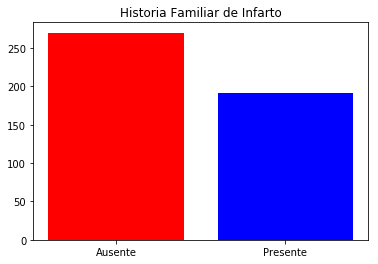

```python
g_famhist = pd.crosstab(index=datos_heart["famhist"],columns="count")
alto = [g_famhist['count'][0], g_famhist['count'][1]]
barras = ('Ausente', 'Presente')
y_pos = np.arange(len(barras))
plt.bar(y_pos, alto, color=['red','blue'])
plt.xticks(y_pos, barras)
plt.title("Historia Familiar de Infarto")
```

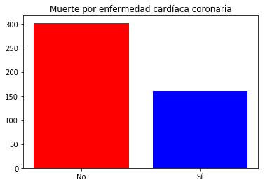

```python
g_chd = pd.crosstab(index=datos_heart["chd"],columns="count")
clases = [g_chd['count'][0], g_chd['count'][1]]
barras = ('No', 'Sí')
y_pos = np.arange(len(barras))
plt.bar(y_pos, clases, color=['red','blue'])
plt.xticks(y_pos, barras)
plt.title("Muerte por enfermedad cardíaca coronaria")
```

#### e) Realice gráficos tipo boxplot para encontrar los datos atípicos en esta tabla de datos.

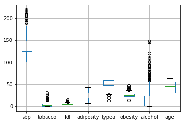

```python
boxplots = datos_heart.boxplot(return_type='axes')
```

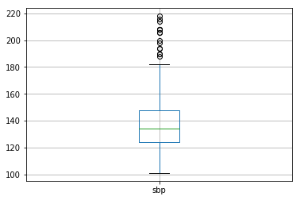

```python
boxplots = datos_heart[['sbp']].boxplot(return_type='axes')
```

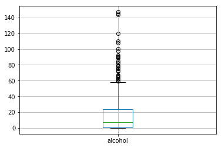

```python
boxplots = datos_heart[['alcohol']].boxplot(return_type='axes')
```

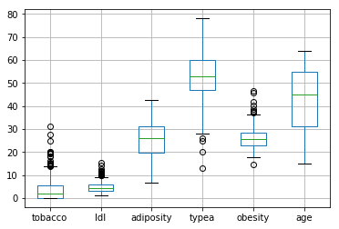

```python
boxplots = datos_heart.drop(['sbp','alcohol'], 1).boxplot(return_type='axes')
```

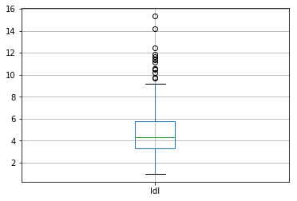

```python
boxplots = datos_heart[['ldl']].boxplot(return_type='axes')
```

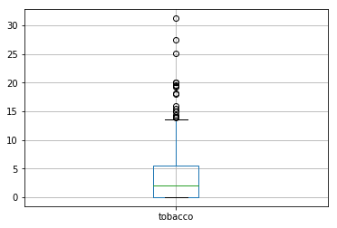

```python
boxplots = datos_heart[['tobacco']].boxplot(return_type='axes')
```

#### f ) Realice histogramas, gráficos de la función de densidad y test de normalidad para al menosdos variables de esta tabla de datos.

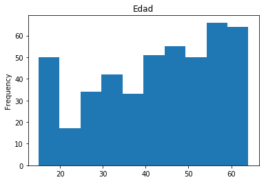

```python
histogramaEdad = datos_heart['age'].plot(kind='hist',title='Edad')
```

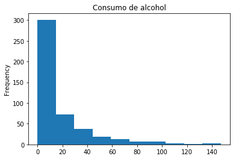

```python
histogramaAlcohol = datos_heart['alcohol'].plot(kind='hist',title='Consumo de alcohol')
```

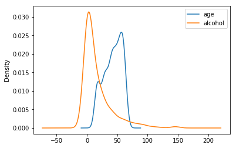

```python
densidad = datos_heart[['age','alcohol']].plot(kind='density')
```

```
EDAD
(0.9370468258857727, 4.594895969788071e-13)
No sigue la curva Normal (Se rechaza H0)
```

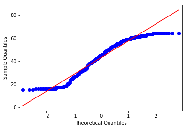

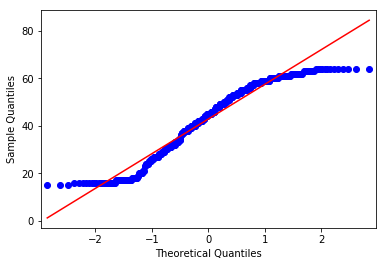

```python
print('EDAD')
shapiro_resultados = scipy.stats.shapiro(datos_heart['age'])
print(shapiro_resultados)
p_value = shapiro_resultados[1]
alpha = 0.05
if p_value > alpha:
    print('Sí sigue la curva Normal (No se rechaza H0)')
else:
    print('No sigue la curva Normal (Se rechaza H0)')


qqplot(datos_heart.age, line='s')
```

```
Obesidad
(0.96074378490448, 9.225323838180088e-10)
No sigue la curva Normal (Se rechaza H0)
```

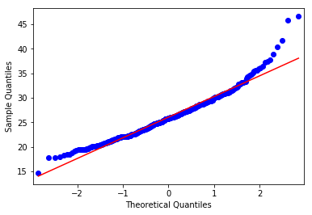

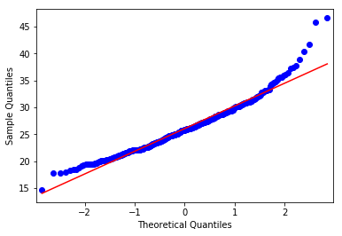

```python
print('Obesidad')
shapiro_resultados = scipy.stats.shapiro(datos_heart['obesity'])
print(shapiro_resultados)
p_value = shapiro_resultados[1]
alpha = 0.05
if p_value > alpha:
    print('Sí sigue la curva Normal (No se rechaza H0)')
else:
    print('No sigue la curva Normal (Se rechaza H0)')


qqplot(datos_heart.obesity, line='s')
```

#### g. Realice al menos dos scatter plot individuales y un gráfi co de todas las variables 2 a 2 usando el paquete Seaborn

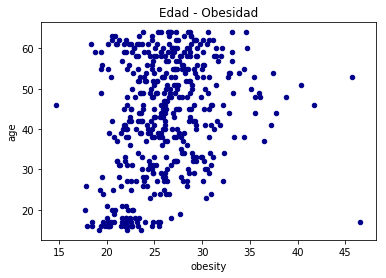

```python
a = datos_heart[['age','obesity']].plot.scatter(x='obesity',y='age',c='DarkBlue', title='Edad - Obesidad')
```

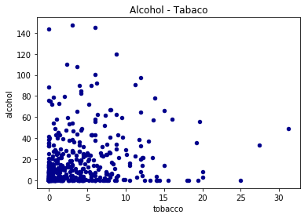

```python
b = datos_heart[['alcohol','tobacco']].plot.scatter(x='tobacco',y='alcohol',c='DarkBlue', title='Alcohol - Tabaco')
```

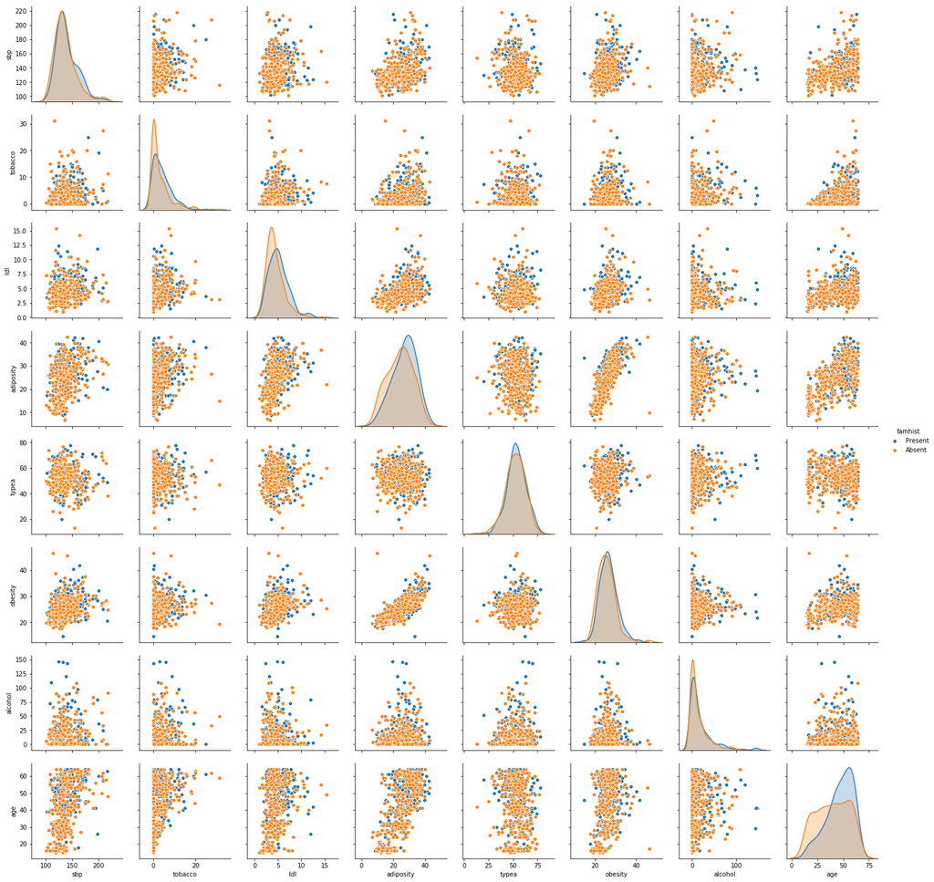

```python
import seaborn as sns
sns.pairplot(datos_heart, hue='famhist', size=2.5)
```

#### h. Calcule y grafique la matriz de correlaciones.

```
                sbp   tobacco       ldl  adiposity     typea   obesity  \
sbp        1.000000  0.212247  0.158296   0.356500 -0.057454  0.238067
tobacco    0.212247  1.000000  0.158905   0.286640 -0.014608  0.124529
ldl        0.158296  0.158905  1.000000   0.440432  0.044048  0.330506
adiposity  0.356500  0.286640  0.440432   1.000000 -0.043144  0.716556
typea     -0.057454 -0.014608  0.044048  -0.043144  1.000000  0.074006
obesity    0.238067  0.124529  0.330506   0.716556  0.074006  1.000000
alcohol    0.140096  0.200813 -0.033403   0.100330  0.039498  0.051620
age        0.388771  0.450330  0.311799   0.625954 -0.102606  0.291777

            alcohol       age
sbp        0.140096  0.388771
tobacco    0.200813  0.450330
ldl       -0.033403  0.311799
adiposity  0.100330  0.625954
typea      0.039498 -0.102606
obesity    0.051620  0.291777
alcohol    1.000000  0.101125
age        0.101125  1.000000
```

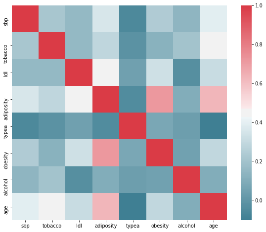

```python
import matplotlib.pyplot as plt
import numpy as np
corr = datos_heart.corr()
print(corr)
print("\n\n \n")
f, ax = plt.subplots(figsize=(10, 8))
graf = sns.heatmap(corr, mask=np.zeros_like(corr, dtype=np.bool), cmap=sns.diverging_palette(220, 10, as_cmap=True),
            square=True, ax=ax)
```

## --------------------------------------------------------------------------------------------------------------------------------

### Ejercicion 3

#### Considere la siguiente tabla datos, la cual contiene las importaciones hechas por los países centroamericanos, provenientes de México, entre 1979 y 1988

```python
os.chdir("D:/ProyectosGit/MineriaDatos/csv/")
datos_mex = pd.read_csv('ImportacionesMexico.csv',delimiter=';',decimal=",",index_col=0)
print(datos_mex)
```

```
      Costa Rica  El Salvador  Guatemala  Honduras  Nicaragua  Panama
1979        44.4         27.2       45.6      20.0        6.0    14.1
1980        75.5         11.8       58.9      22.6       17.8    14.4
1981       110.7         50.6      128.3      17.2      119.4   118.5
1982        80.3         70.6      102.2      15.2      154.9   146.1
1983        81.6         82.3       89.0      35.1      169.4   127.1
1984        76.4         97.4      185.0      51.0       75.5   129.0
1985        32.0         89.5      195.3      31.1       33.4   110.2
1986        55.5         63.1       66.3      24.4        9.7    66.7
1987        74.3         72.6       76.3      28.1       11.2   110.7
1988        84.5         76.2       80.1      29.5       11.8   110.2
```

#### clase ACP

```python
from prince import PCA
class ACP:
    def __init__(self, datos, n_componentes = 5):
        self.__datos = datos
        self.__modelo = PCA(n_components = n_componentes).fit(self.__datos)
        self.__correlacion_var = self.__modelo.column_correlations(datos)
        self.__coordenadas_ind = self.__modelo.row_coordinates(datos)
        self.__contribucion_ind = self.__modelo.row_contributions(datos)
        self.__cos2_ind = self.__modelo.row_cosine_similarities(datos)
        self.__var_explicada = [x * 100 for x in self.__modelo.explained_inertia_]
    @property
    def datos(self):
        return self.__datos
    @datos.setter
    def datos(self, datos):
        self.__datos = datos
    @property
    def modelo(self):
        return self.__modelo
    @property
    def correlacion_var(self):
        return self.__correlacion_var
    @property
    def coordenadas_ind(self):
        return self.__coordenadas_ind
    @property
    def contribucion_ind(self):
        return self.__contribucion_ind
    @property
    def cos2_ind(self):
        return self.__cos2_ind
    @property
    def var_explicada(self):
        return self.__var_explicada
    def plot_plano_principal(self, ejes = [0, 1], ind_labels = True, titulo = 'Plano Principal'):
        x = self.coordenadas_ind[ejes[0]].values
        y = self.coordenadas_ind[ejes[1]].values
        plt.style.use('seaborn-whitegrid')
        plt.scatter(x, y, color = 'gray')
        plt.title(titulo)
        plt.axhline(y = 0, color = 'dimgrey', linestyle = '--')
        plt.axvline(x = 0, color = 'dimgrey', linestyle = '--')
        inercia_x = round(self.var_explicada[ejes[0]], 2)
        inercia_y = round(self.var_explicada[ejes[1]], 2)
        plt.xlabel('Componente ' + str(ejes[0]) + ' (' + str(inercia_x) + '%)')
        plt.ylabel('Componente ' + str(ejes[1]) + ' (' + str(inercia_y) + '%)')
        if ind_labels:
            for i, txt in enumerate(self.coordenadas_ind.index):
                plt.annotate(txt, (x[i], y[i]))
    def plot_circulo(self, ejes = [0, 1], var_labels = True, titulo = 'Círculo de Correlación'):
        cor = self.correlacion_var.iloc[:, ejes].values
        plt.style.use('seaborn-whitegrid')
        c = plt.Circle((0, 0), radius = 1, color = 'steelblue', fill = False)
        plt.gca().add_patch(c)
        plt.axis('scaled')
        plt.title(titulo)
        plt.axhline(y = 0, color = 'dimgrey', linestyle = '--')
        plt.axvline(x = 0, color = 'dimgrey', linestyle = '--')
        inercia_x = round(self.var_explicada[ejes[0]], 2)
        inercia_y = round(self.var_explicada[ejes[1]], 2)
        plt.xlabel('Componente ' + str(ejes[0]) + ' (' + str(inercia_x) + '%)')
        plt.ylabel('Componente ' + str(ejes[1]) + ' (' + str(inercia_y) + '%)')
        for i in range(cor.shape[0]):
            plt.arrow(0, 0, cor[i, 0] * 0.95, cor[i, 1] * 0.95, color = 'steelblue',
                      alpha = 0.5, head_width = 0.05, head_length = 0.05)
            if var_labels:
                plt.text(cor[i, 0] * 1.05, cor[i, 1] * 1.05, self.correlacion_var.index[i],
                         color = 'steelblue', ha = 'center', va = 'center')
    def plot_sobreposicion(self, ejes = [0, 1], ind_labels = True,
                      var_labels = True, titulo = 'Sobreposición Plano-Círculo'):
        x = self.coordenadas_ind[ejes[0]].values
        y = self.coordenadas_ind[ejes[1]].values
        cor = self.correlacion_var.iloc[:, ejes]
        scale = min((max(x) - min(x)/(max(cor[ejes[0]]) - min(cor[ejes[0]]))),
                    (max(y) - min(y)/(max(cor[ejes[1]]) - min(cor[ejes[1]])))) * 0.7
        cor = self.correlacion_var.iloc[:, ejes].values
        plt.style.use('seaborn-whitegrid')
        plt.axhline(y = 0, color = 'dimgrey', linestyle = '--')
        plt.axvline(x = 0, color = 'dimgrey', linestyle = '--')
        inercia_x = round(self.var_explicada[ejes[0]], 2)
        inercia_y = round(self.var_explicada[ejes[1]], 2)
        plt.xlabel('Componente ' + str(ejes[0]) + ' (' + str(inercia_x) + '%)')
        plt.ylabel('Componente ' + str(ejes[1]) + ' (' + str(inercia_y) + '%)')
        plt.scatter(x, y, color = 'gray')
        if ind_labels:
            for i, txt in enumerate(self.coordenadas_ind.index):
                plt.annotate(txt, (x[i], y[i]))
        for i in range(cor.shape[0]):
            plt.arrow(0, 0, cor[i, 0] * scale, cor[i, 1] * scale, color = 'steelblue',
                      alpha = 0.5, head_width = 0.05, head_length = 0.05)
            if var_labels:
                plt.text(cor[i, 0] * scale * 1.15, cor[i, 1] * scale * 1.15,
                         self.correlacion_var.index[i],
                         color = 'steelblue', ha = 'center', va = 'center')
```

#### 1) En el plano principal encuentre los clústeres o segmentos.

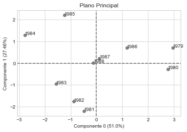

```python
acp = ACP(datos_mex,n_componentes=6)
acp.plot_plano_principal()
```

Clústers:

[output not shown]

#### 2) En el círculo de correlación determine la correlación entre las variables e interprételas

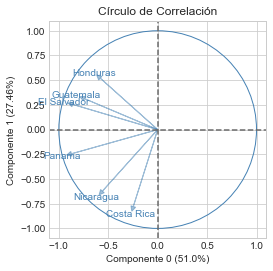

```python
acp.plot_circulo()
```

Se puede observar una correlación positiva entre las variables Guatemala y El Salvador, por lo que cuando Guatemala importa productos, El Salvador también lo hará. Sin embargo, estas dos variables son incorrelacionadas con Costa Rica, por lo que las importaciones hechas por estos dos países y Costa Rica no tienen ninguna relación. Lo mismo sucede con Honduras y Nicaragua, son incorrelacionadas. Costa Rica y Nicaragua tienden a correlacionarse positivamente, por lo que cuando uno de los dos países importa el otro también lo hace.

#### 3) Explique la formación de los clústeres basado en la sobreposición del circulo y el plano, interprete (los años 1987 y 1988 no se deben interpretar ya que están muy mal representados en este plano, debido a que los cosenos cuadrados de estos años en las componentes 1 y 2 son muy bajos).

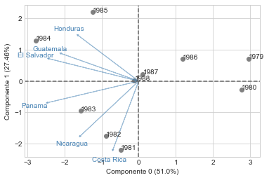

```python
acp.plot_sobreposicion()
```

El primer clúster (1979, 1980, 1986) se forma debido a que los países importaron poco en esos años.

El segundo clúster (1984 y 1985) existe ya que Honduras, Guatemala y El Salvador importaron más en los años presentes en ese clúster.

El tercer clúster representa la mayor cantidad de importaciones por parte de Costa Rica, Nicaragua y Panamá

#### b) En el plano y circulo 1-3 (componentes 1 y 3) interprete los años 1987 y 1988.

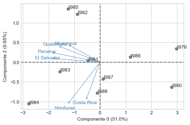

```python
acp.plot_sobreposicion(ejes = [0, 2])
```

Al analizar el componente 1 y 3, en 1987 y 1988 Costa Rica y Honduras importaron más desde México, mientras que países como Nicaragua, Guatemala, Panamá y El Salvador casi no lo hicieron.

## --------------------------------------------------------------------------------------------------------------------

### Ejercicio 4.

#### [25 puntos] Para la tabla del ejercicio 2 realice lo siguiente:

#### 1) En el plano principal encuentre los clústeres o segmentos.

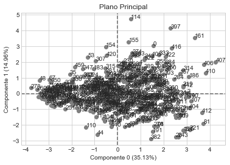

```python
datos_heart2 = pd.DataFrame(data=datos_heart, columns=['sbp', 'tobacco', 'ldl', 'adiposity', 'typea', 'obesity', 'alcohol', 'age'])

acp = ACP(datos_heart2,n_componentes=8)
acp.plot_plano_principal()
```

#### 2) En el círculo de correlación determine la correlación entre las variables e interprételas

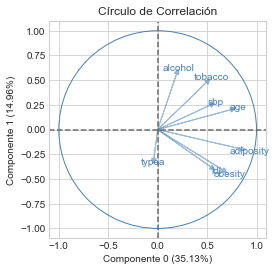

```python
acp.plot_circulo()
```

La variable ldl (low densiity lipoprotein cholesterol) y obesity tienen una correlación positiva, por lo que cuando el nivel de obesity crece también lo hace el nivel de ldl. Por otro lado, existe una correlación negativa entre alcohol y typea (type-A behavior), por lo que cuando una de estas dos variables crece, la otra decrece. La variable adiposity y la variable alcohol están incorrelacionadas. Lo mismo sucede cuando se analiza tobacco con respecto a ldl o obesity. Sbp (systolic blood pressure) se correlaciona positivamente con age, por lo que entre más edad tenga el sujeto es más probable que los niveles de sbp sean mayores.

#### 3) Explique la formación de los clústeres basado en la sobreposición del circulo y el plano, interprete, utilice para esto 3 clústeres

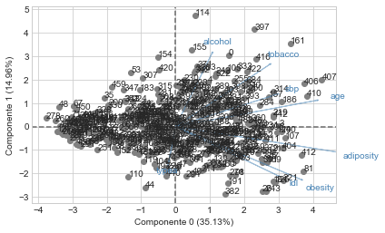

```python
acp.plot_sobreposicion()
```

Se forma un clúster a la izquierda que representa los sujetos tienden a presentar niveles de typeA, con las demás variables tienen niveles bajos.

Existe otro clúster en el cuadrante inferior positivo, donde los sujetos tienden a tener niveles altos de ldl, obesity y adiposity.

Por ultimo se forma un clúster superior, que indica los sujetos que presentan niveles altos en alcohol, tobacco, sbp y edad, mientras que tienen niveles bajos de typeA.

#### b) Usando todas las variables con famhist y chd recodificadas como códigos disyuntivos completos (variables Dummy), efectué un ACP y de una interpretación siguiendo los siguientes pasos:

#### 1) En el plano principal encuentre los clústeres o segmentos.

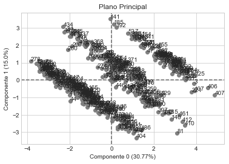

```python
datos_dumm = pd.get_dummies(datos_heart)
acp = ACP(datos_dumm,n_componentes=10)
acp.plot_plano_principal()
```

#### 2) En el círculo de correlación determine la correlación entre las variables e interprételas

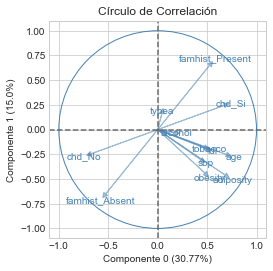

```python
acp.plot_circulo()
```

Las variables tobacco, age, sbp (systolic blood pressure), obesity y adiposity se correlacionan positivamente, por lo que cuando alguna crece, las demás tienden a crecer. Por otro lado, estas variables son incorrelacionadas con famhist_Present y famhist_Absent.

Cuando el individuo presenta historial familiar de enfermedades cardiacas (famhist_present) tendrá un nivel 0 de famhist_Absent, por lo que las variables presentan una correlación negativa perfecta. Lo mismo sucede con las variables chd_No y chd_Si.

Por otro lado, famhist_Absent presenta una correlación positiva con chd_No, lo mismo sucede cuando se analiza chd_si y famhist_Present.

TypeA parece ser una variable independiente.

#### 3) Explique la formación de los clústeres basado en la sobreposición del circulo y el plano, interprete, utilice para esto 3 clústeres

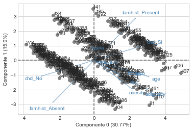

```python
acp.plot_sobreposicion()
```

En el clúster superior se identifican los sujetos que presentan historial familiar y chd (coronary heart desease), ademas presentan nivel superior de typeA con respecto al resto de los sujetos.

El segundo clúster es el cuadrante inferior negativo, son sujetos que no tienen historial familiar ni chd.

El tercer clúster (cuadrante inferior positivo), con niveles altos de tobacco, age, sbp (systolic blood pressure), obesity y adiposity, por lo que son los sujetos con mayor probabilidad a presentar un resultado positivo en el examen de enfermedades cardiacas.

#### c) Cuál de los análisis anteriores le parece más interesante? Porqué?

La parte B del ejercicio 4 (La ultima parte de la tarea), debido a que al introducir 2 variables dummy los individuos en el plano se dispersan de manera peculiar en 3 grupos, mientras que cuando se grafico este problema sin las variables dummy, el grupo era mas disperso y centralizado.